# PM606 project Final Report

Mingzhi_Ye

8/9/2021

# Introduction

This project is conducted by USC Public Health Data Science Department with the great help of City ofo Hope. In this project, I use the CTS data to build a model to predict whether the patient would die in the given time window.I will also analyze several variables to find out whether they are significantly related to the risk of death in the given time window

# Method

## Pre-processing

At first, I remove all predictors whose NA values are more than 1/4. Those predictors are not lack too much values and are probably biased. There is an exception: date_of_death_dt. All the individuals who didn’t die until the end of the study shall be recorded as NA in “date_of_death_dt”. So I keep it and change all individuals’ “date_of_death_dt” to 4000-11-11 if and only is their “decease” is 0.

Second, I remove Some variables that is too related to other variables, which causes colinearity and lead to reduntancy. Such as smoke_statcat and cig_day_avg, or diag_icd1 and diag_icd_dsc1.I remove one of the pair.

Third, I also remove some irrelevant variables, judged by philosophy.

Forth, I also create several new variables. I create “month” recording the month of “discharge_dt”. Then I also create “season” based on “month”. I also create “survive time to record how long do they survive after discharge. I also create”die30“,”die180, “die1800” to record whether they die in 30days 180days or 1800days after discharge.

## Preliminary exploration the data

### Explore and process the ccs code variables

I found that each icd code have more than 2500 categories. If I use the all the ide codes as predictors, they will lead to more than 10000 dummy variables in the LASSO logistic regression and also make the calculate too complex and time consuming. Considering that the processed dataset only have less than 40000 rows, such a big amount of dummy variables will lead to overfitting in the LASSO logistic regression model. So I decide to only keep the ccs codes, which is collapsed from the icd code.

Form the plots, we can find that limited kinds of ccs codes covers most of the individuals. It is the same with ccs code1-4. We can also find that different ccs code have significantly different death time window distribution

#### CCS code name1: diag_ccs1

```
## [1] 239
```

```
## [1] 2597
```

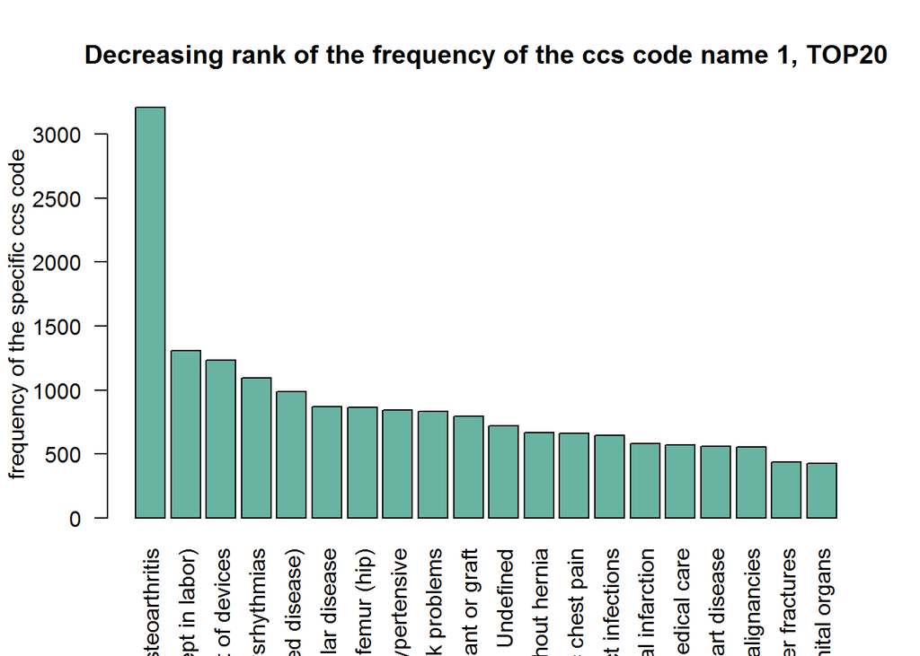

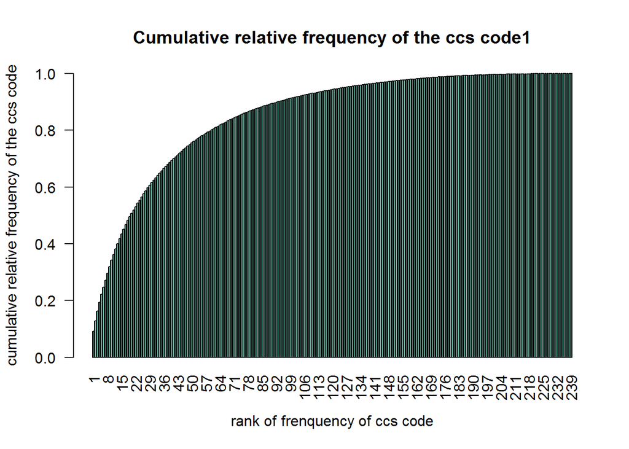

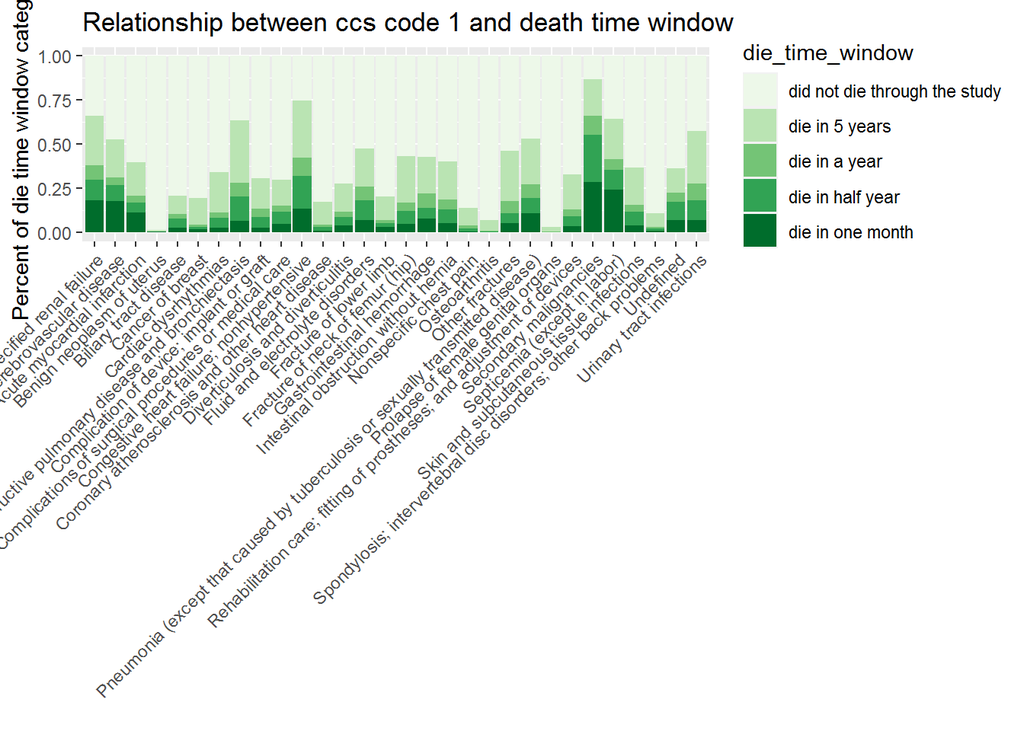

#### CCS code name2: diag_ccs2

```
## [1] 241
```

```
## [1] 2709
```

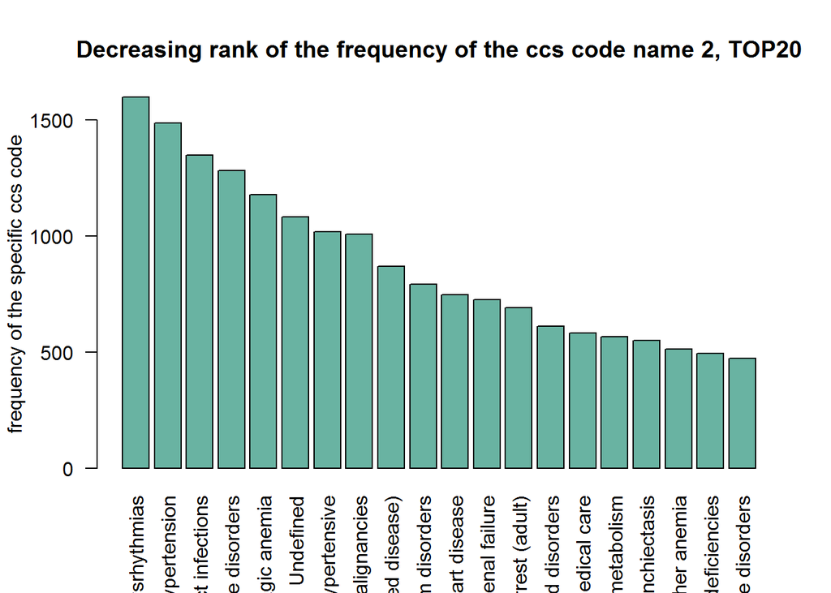

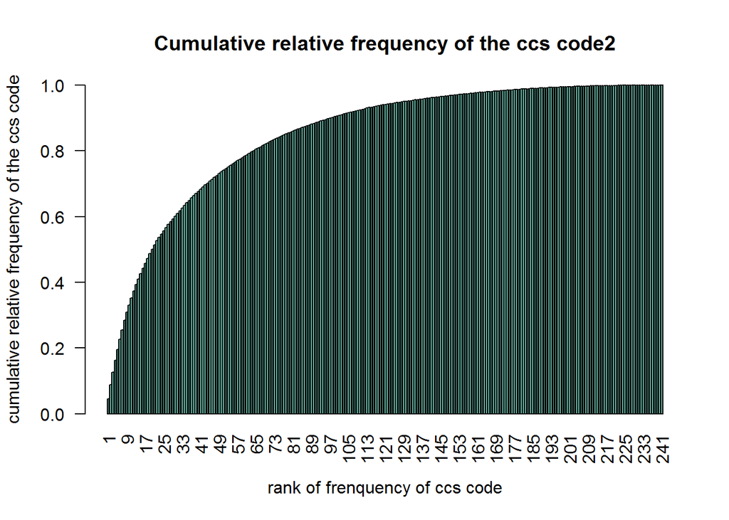

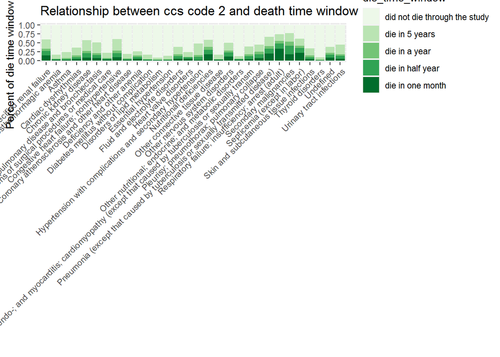

#### CCS code name3: diag_ccs3

```
## [1] 239
```

```
## [1] 2725
```

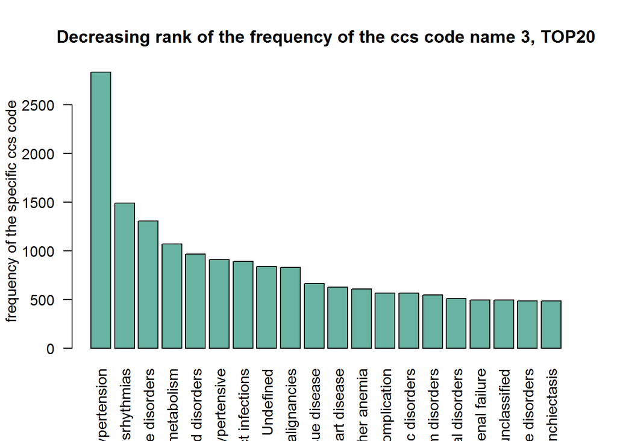

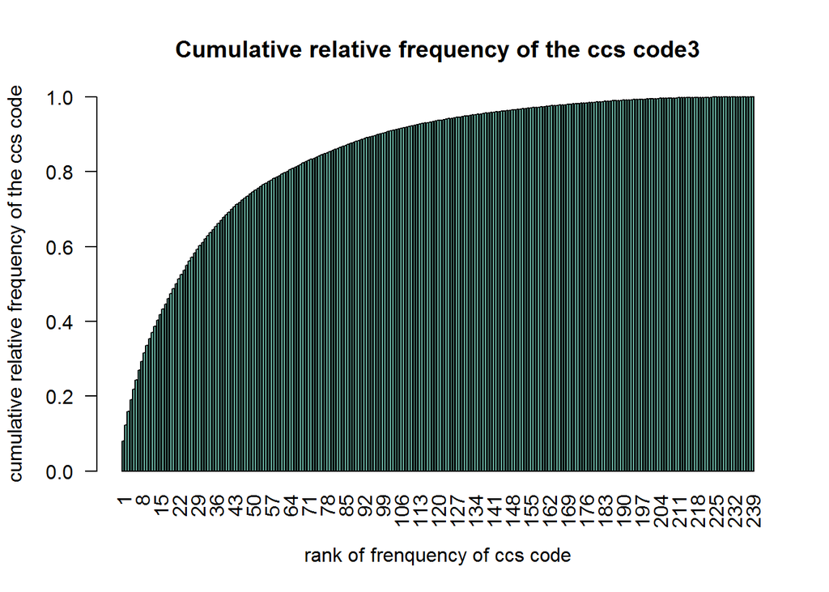

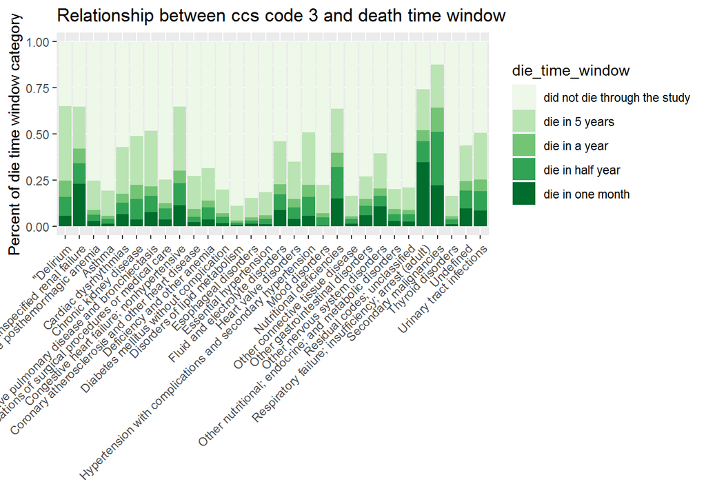

#### CCS code name4: diag_ccs4

```
## [1] 238
```

```
## [1] 2653
```

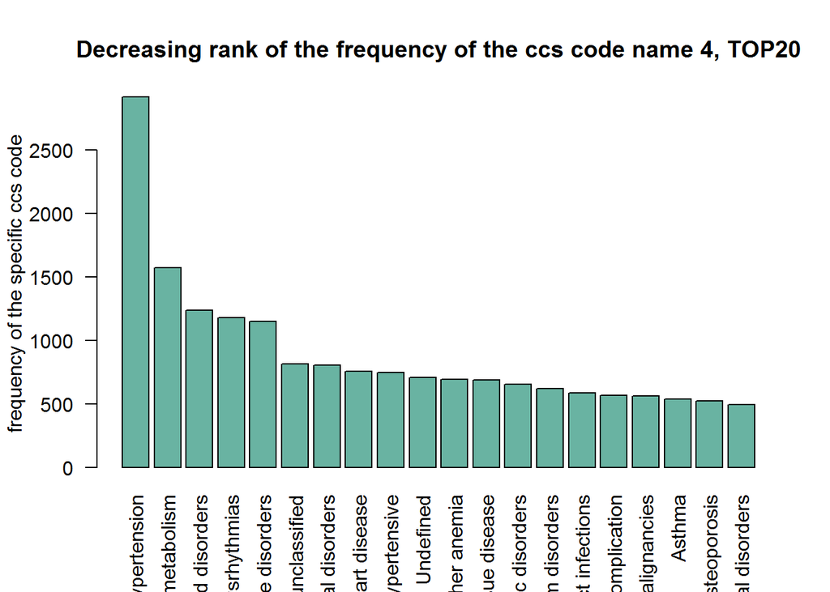

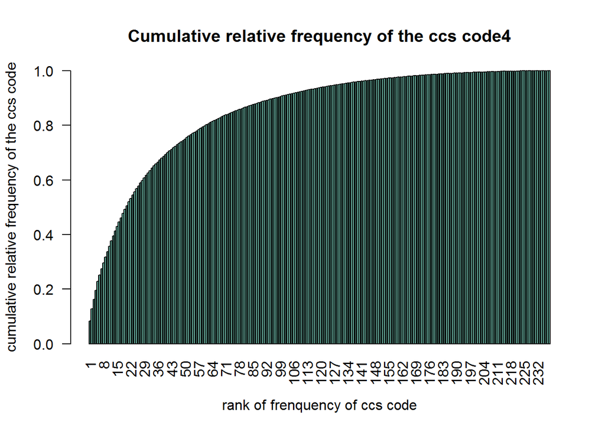

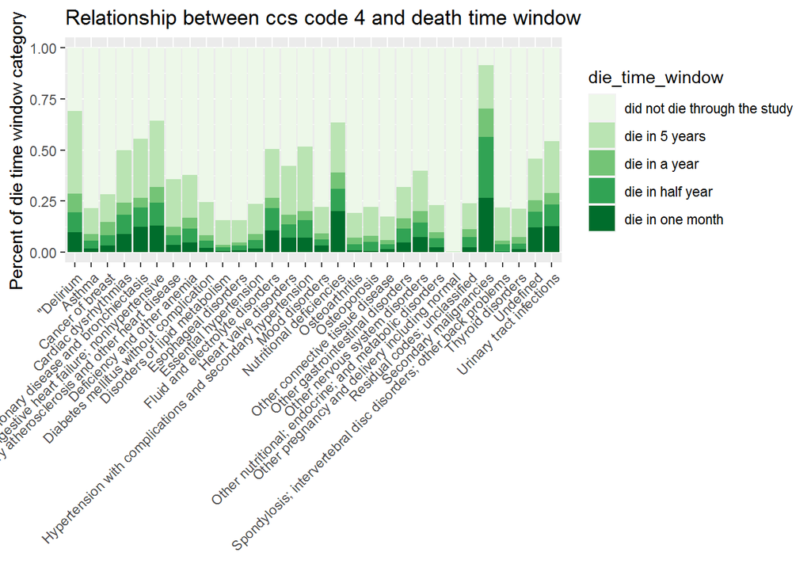

### Relationship between season and death time window

It seems that season doesn’t have a significant influence on death time window distribution

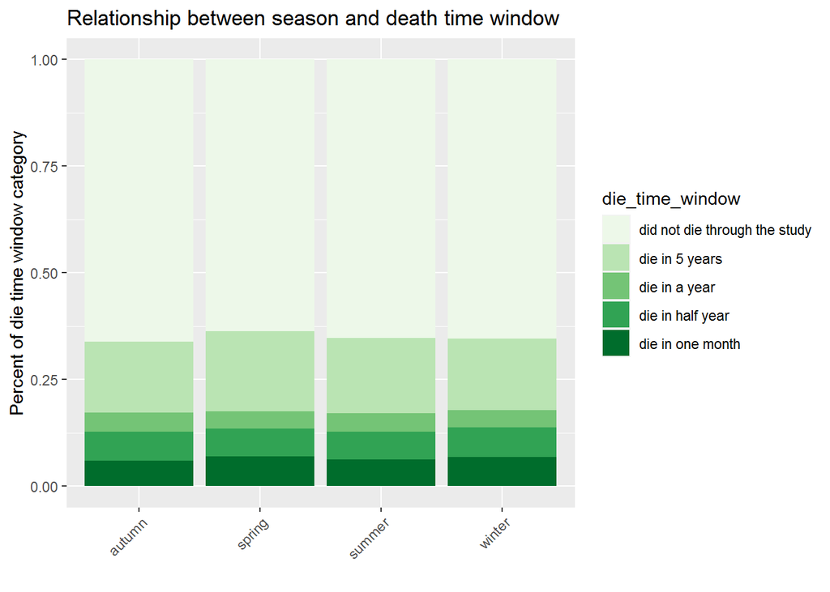

### Relationship between zip code and death time window

We can find that in different zip code areas, the death time window distributions are quite different

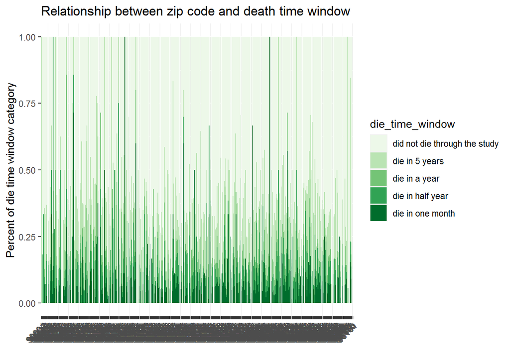

### Relationship between birth place and death time window

It seems that birth place have a significant influence on death time window

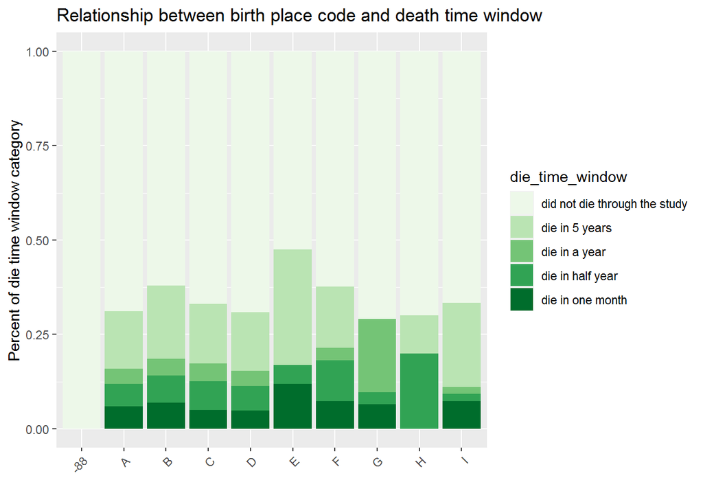

### Relationship between age and death time window

It seems that age have a significant influence on death time window. The older, the more risk of death

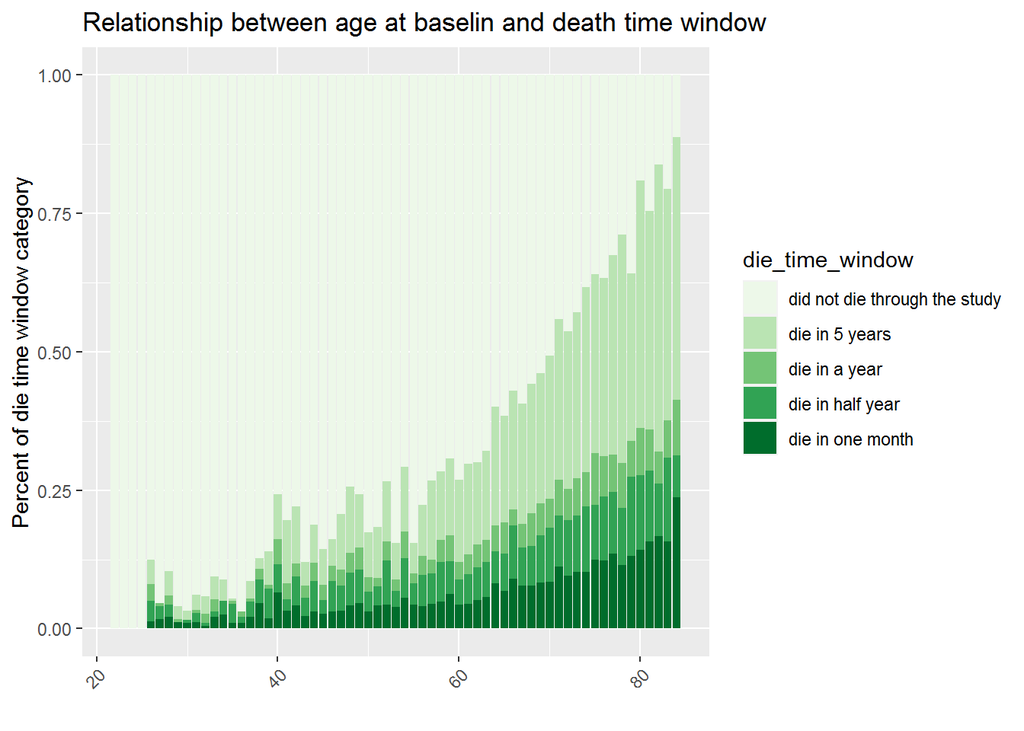

### Relationship between participant race and death time window

It seems that participant race have a significant influence on death time window distributio. The African Americans have the biggest risk of death.

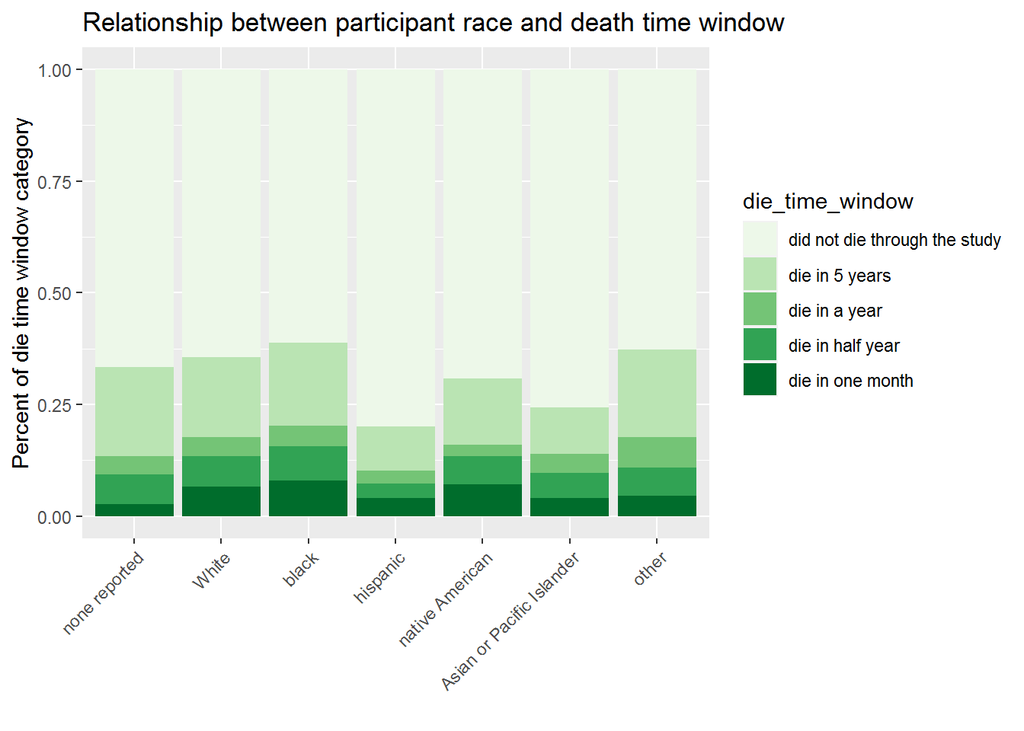

## Build and select models for predicting die30

(die30 indicates whether the individual die in 30 days after discharge)

I will use four models: random forest, LASSO logistic regression, boosting and SVM. Then I will select the best model. I will also use that model to predict die1800. For some variables with more than 50 categories, I only keep the 50 most frequent categories and mark other categories as “other”.

### Random forest

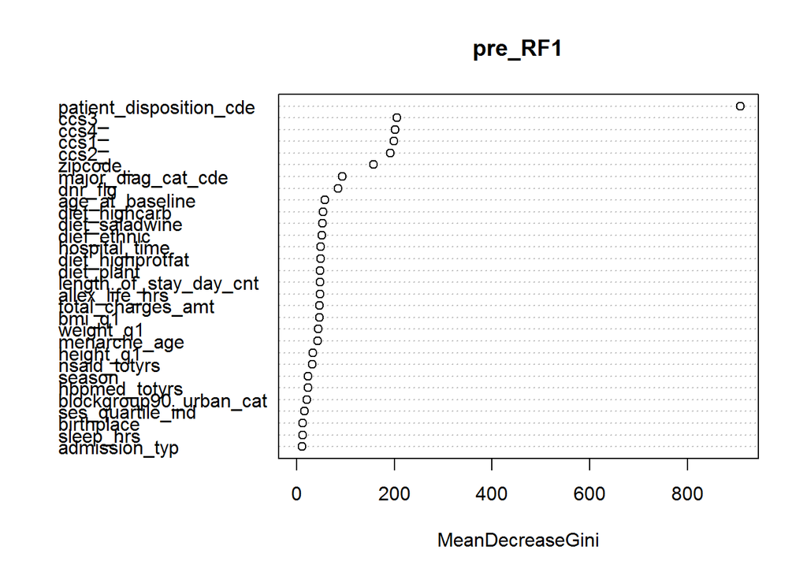

```
##                            MeanDecreaseGini
## ses_quartile_ind                 16.7414633
## blockgroup90_urban_cat           21.3877469
## hysterectomy_ind                  5.6186164
## bilateral_mastectomy_ind          0.5694043
## bilateral_oophorectomy_ind        5.1737893
## age_at_baseline                  58.0258426
## adopted                           0.9883099
## twin                              1.0059664
## birthplace                       12.2884274
## participant_race                  7.5773925
## menarche_age                     43.9027853
## oralcntr_ever_q1                  8.1147141
## preg_ever_q1                      5.0839590
## height_q1                        33.3848338
## weight_q1                        44.8022885
## bmi_q1                           46.4593427
## allex_life_hrs                   47.6316548
## alchl_analyscat                  11.2206874
## brca                              4.9621503
## mammo_ever_q1                     2.8490895
## hbpmed_totyrs                    23.1278744
## nsaid_totyrs                     31.7869027
## sleep_hrs                        12.0764941
## diet_plant                       48.8326855
## diet_highprotfat                 49.1342059
## diet_highcarb                    54.1840777
## dief_ethnic                      51.4565758
## diet_saladwine                   52.9618185
## smoke_statcat                     9.7935775
## asthma_q3                         3.9398022
## insulin_daily                     2.1858167
## aceinhb_daily                     4.0282047
## othhbp_daily                      5.4063048
## tamox_daily                       4.2321221
## steroid_daily                     3.5832532
## brondil_daily                     4.1292450
## cholmed_daily                     4.8079272
## antidep_daily                     4.0523751
## admission_typ                    11.7792268
## length_of_stay_day_cnt           47.6371265
## dnr_flg                          85.1105531
## major_diag_cat_cde               93.7307453
## patient_care_typ                  4.7807270
## patient_disposition_cde         908.4115643
## total_charges_amt                46.8404234
## diag_poa1                         2.2138213
## diag_poa2                         6.8399736
## diag_poa3                         6.3980379
## diag_poa4                         5.4213020
## hospital_time                    49.3259845
## season                           23.8409083
## ccs1_                           199.1781398
## ccs2_                           191.4893347
## ccs3_                           205.1382918
## ccs4_                           201.3648095
## zipcode_                        158.0996676
```

[output not shown]

```
## Area under the curve: 0.7356
```

### LASSO logistic classification

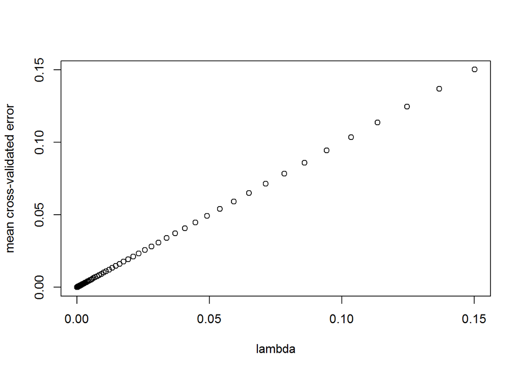

```
##                                                       names       Beta
## 1                               patient_disposition_cde.X11  6.4072442
## 2                               patient_disposition_cde.X20  4.9337482
## 3                                    major_diag_cat_cde.X25  4.1710452
## 4                               patient_disposition_cde.X51  3.1185925
## 5                               patient_disposition_cde.X50  2.1982525
## 6                               patient_disposition_cde.X13  1.8960046
## 7                              ccs1_.Secondary.malignancies  1.4033413
## 8                                patient_disposition_cde.X2  1.0710238
## 9                                                 dnr_flg.Y  1.0356694
## 10                             ccs4_.Secondary.malignancies  0.9863471
## 11                                   major_diag_cat_cde.X17  0.8886343
## 12                              patient_disposition_cde.X63  0.8790254
## 13                ccs1_.Acute.and.unspecified.renal.failure  0.8633028
## 14                ccs4_.Acute.and.unspecified.renal.failure  0.8431186
## 15                             ccs2_.Secondary.malignancies  0.8329342
## 16                               patient_disposition_cde.X1 -0.8042216
## 17                           ccs2_.Nutritional.deficiencies  0.7558373
## 18 ccs1_.Respiratory.failure..insufficiency..arrest..adult.  0.7458320
## 19                                         admission_typ.X1 -0.7306056
## 20                             ccs3_.Secondary.malignancies  0.6507283
```

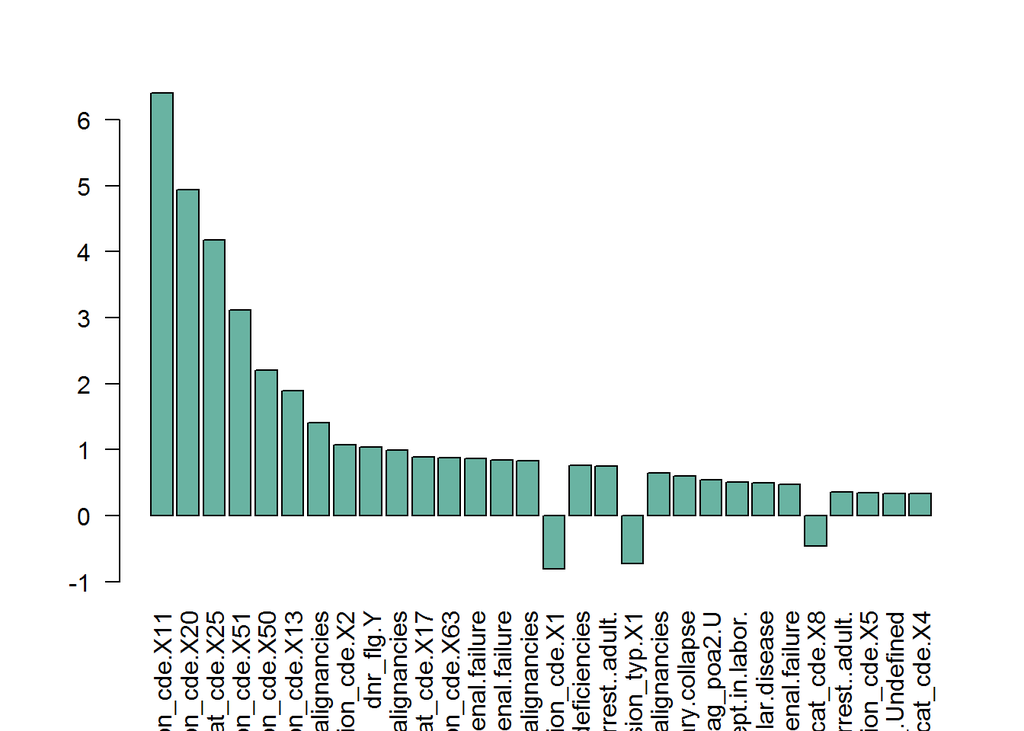

```
## [1] "optimal lambda:"
```

```
## [1] 0.0009002293
```

```
## [1] "AUC for LASSO in the test set:"
```

```
## Area under the curve: 0.9212
```

### Boosting

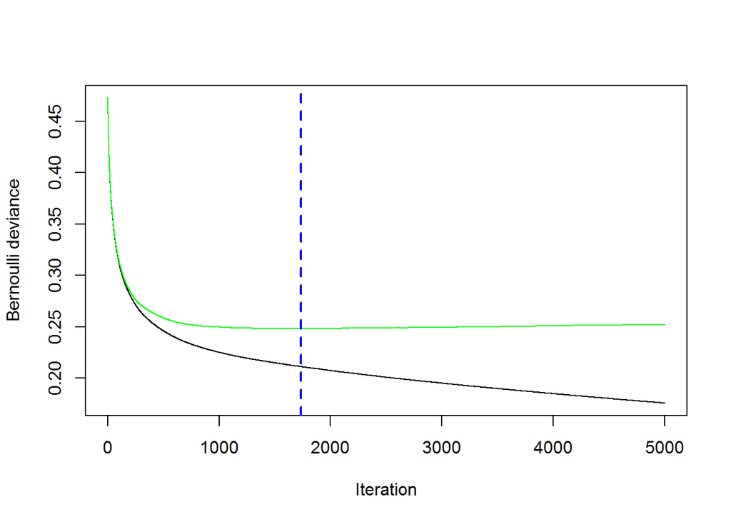

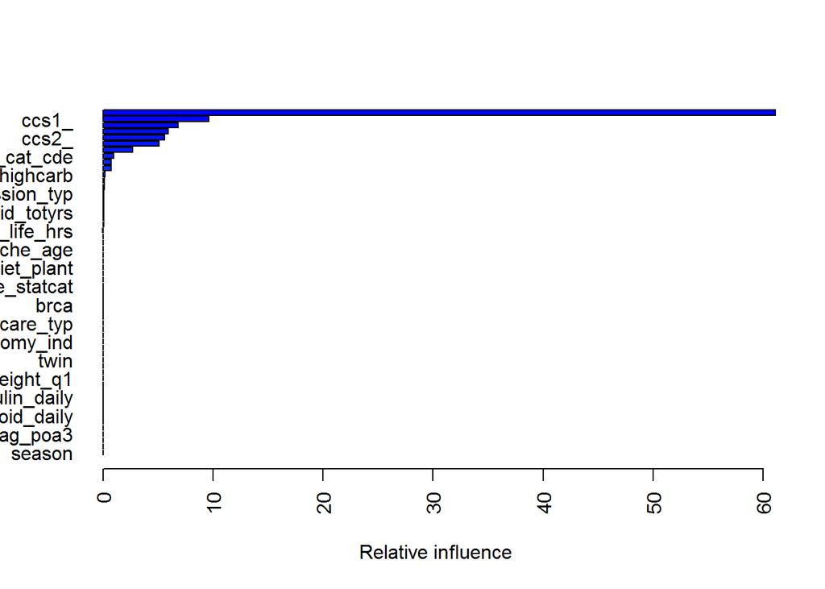

```
##                                                   var      rel.inf
## patient_disposition_cde       patient_disposition_cde 61.103784024
## ccs1_                                           ccs1_  9.594899812
## ccs3_                                           ccs3_  6.799722234
## ccs4_                                           ccs4_  5.929404956
## ccs2_                                           ccs2_  5.591591298
## zipcode_                                     zipcode_  5.079880705
## dnr_flg                                       dnr_flg  2.670469284
## major_diag_cat_cde                 major_diag_cat_cde  0.966645063
## length_of_stay_day_cnt         length_of_stay_day_cnt  0.717910883
## age_at_baseline                       age_at_baseline  0.714453113
## diet_highcarb                           diet_highcarb  0.150305244
## diet_saladwine                         diet_saladwine  0.098389547
## sleep_hrs                                   sleep_hrs  0.097658224
## admission_typ                           admission_typ  0.078648741
## bmi_q1                                         bmi_q1  0.076504809
## total_charges_amt                   total_charges_amt  0.050723350
## nsaid_totyrs                             nsaid_totyrs  0.047936626
## diag_poa2                                   diag_poa2  0.037275287
## weight_q1                                   weight_q1  0.035253287
## allex_life_hrs                         allex_life_hrs  0.033388595
## diet_highprotfat                     diet_highprotfat  0.026692564
## birthplace                                 birthplace  0.023478619
## menarche_age                             menarche_age  0.020719332
## dief_ethnic                               dief_ethnic  0.019460037
## tamox_daily                               tamox_daily  0.005372312
## diet_plant                                 diet_plant  0.005272608
## alchl_analyscat                       alchl_analyscat  0.004956879
## ses_quartile_ind                     ses_quartile_ind  0.004685884
## smoke_statcat                           smoke_statcat  0.002912967
## hbpmed_totyrs                           hbpmed_totyrs  0.002760106
## brondil_daily                           brondil_daily  0.002388429
## brca                                             brca  0.002316795
## cholmed_daily                           cholmed_daily  0.001604349
## participant_race                     participant_race  0.001487529
## patient_care_typ                     patient_care_typ  0.001046506
## blockgroup90_urban_cat         blockgroup90_urban_cat  0.000000000
## hysterectomy_ind                     hysterectomy_ind  0.000000000
## bilateral_mastectomy_ind     bilateral_mastectomy_ind  0.000000000
## bilateral_oophorectomy_ind bilateral_oophorectomy_ind  0.000000000
## adopted                                       adopted  0.000000000
## twin                                             twin  0.000000000
## oralcntr_ever_q1                     oralcntr_ever_q1  0.000000000
## preg_ever_q1                             preg_ever_q1  0.000000000
## height_q1                                   height_q1  0.000000000
## mammo_ever_q1                           mammo_ever_q1  0.000000000
## asthma_q3                                   asthma_q3  0.000000000
## insulin_daily                           insulin_daily  0.000000000
## aceinhb_daily                           aceinhb_daily  0.000000000
## othhbp_daily                             othhbp_daily  0.000000000
## steroid_daily                           steroid_daily  0.000000000
## antidep_daily                           antidep_daily  0.000000000
## diag_poa1                                   diag_poa1  0.000000000
## diag_poa3                                   diag_poa3  0.000000000
## diag_poa4                                   diag_poa4  0.000000000
## hospital_time                           hospital_time  0.000000000
## season                                         season  0.000000000
```

```
## [1] 1734
```

```
## Using 1734 trees...
```

[output not shown]

```
## Area under the curve: 0.9264
```

### SVM

```
## [Tune] Started tuning learner classif.ksvm for parameter set:
```

```
##       Type len Def  Constr Req Tunable Trafo
## C discrete   -   - 3,4,5,6   -    TRUE     -
```

```
## With control class: TuneControlGrid
```

```
## Imputation value: 1
```

```
## [Tune-x] 1: C=3
```

```
## [Tune-y] 1: mmce.test.mean=0.0385006; time: 8.1 min
```

```
## [Tune-x] 2: C=4
```

```
## [Tune-y] 2: mmce.test.mean=0.0387034; time: 8.0 min
```

```
## [Tune-x] 3: C=5
```

```
## [Tune-y] 3: mmce.test.mean=0.0387846; time: 8.1 min
```

```
## [Tune-x] 4: C=6
```

```
## [Tune-y] 4: mmce.test.mean=0.0388657; time: 8.5 min
```

```
## [Tune] Result: C=3 : mmce.test.mean=0.0385006
```

```
## [1] 3
```

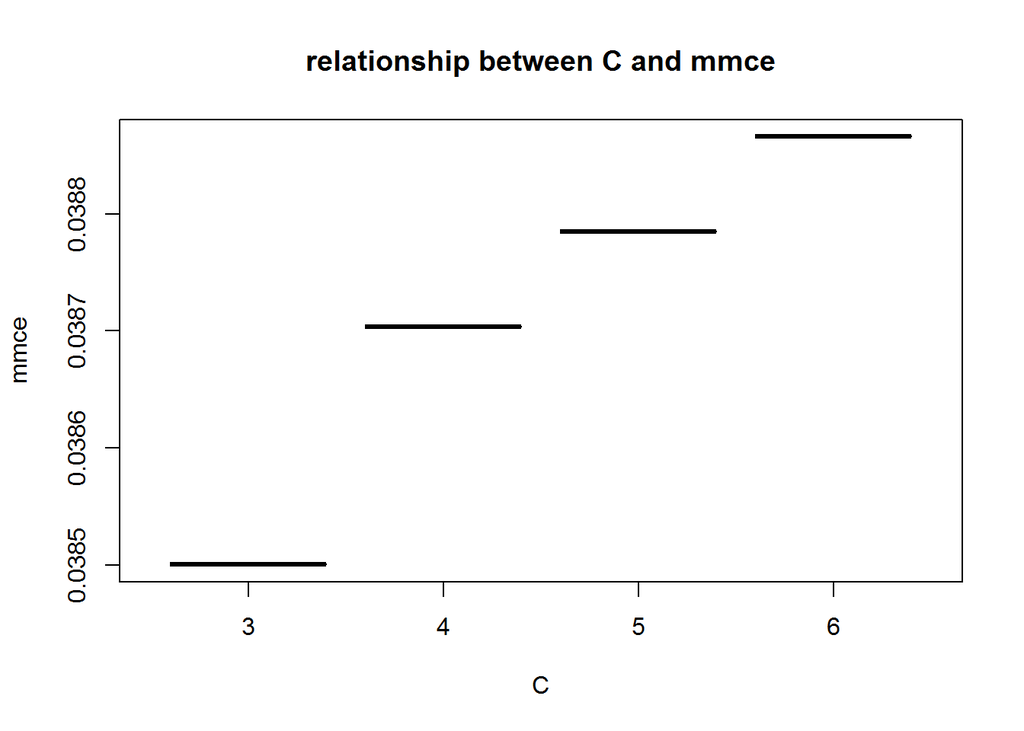

```
## [1] "AUC for SVM in the test set:"
```

```
## Area under the curve: 0.7238
```

### Model selection

Boosting has the best AUC. And AUC is a very good measurement evaluating the models because it consider not only sensitivity but also specificity

## Boosting for die1800

(die1800 indicates whether the individual die in 1800 days after discharge)

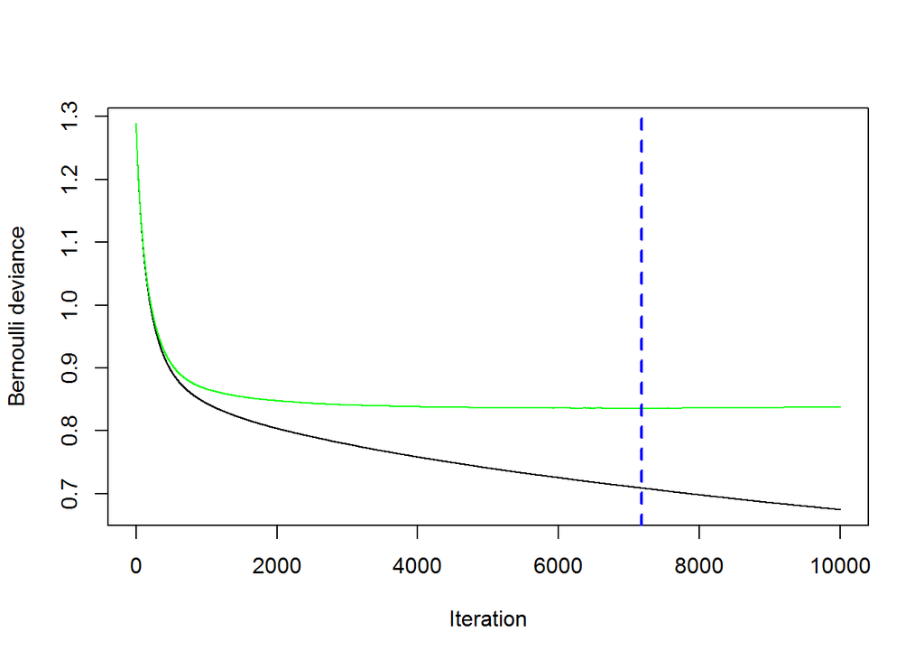

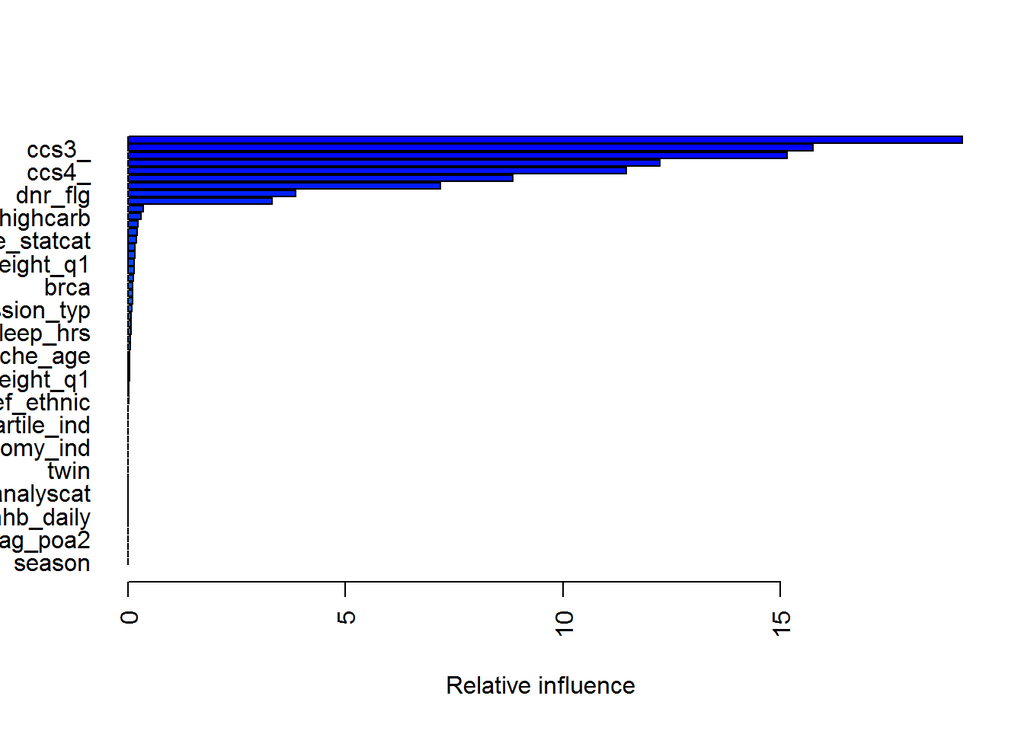

```
##                                                   var      rel.inf
## ccs1_                                           ccs1_ 19.185497876
## ccs3_                                           ccs3_ 15.751861861
## ccs2_                                           ccs2_ 15.163238825
## age_at_baseline                       age_at_baseline 12.236165820
## ccs4_                                           ccs4_ 11.467086200
## zipcode_                                     zipcode_  8.841909603
## patient_disposition_cde       patient_disposition_cde  7.192631006
## dnr_flg                                       dnr_flg  3.864884021
## major_diag_cat_cde                 major_diag_cat_cde  3.320398701
## hbpmed_totyrs                           hbpmed_totyrs  0.357107085
## diet_highcarb                           diet_highcarb  0.300122182
## steroid_daily                           steroid_daily  0.230229567
## length_of_stay_day_cnt         length_of_stay_day_cnt  0.204767133
## smoke_statcat                           smoke_statcat  0.197486421
## diet_highprotfat                     diet_highprotfat  0.161533873
## insulin_daily                           insulin_daily  0.157786946
## weight_q1                                   weight_q1  0.150815326
## participant_race                     participant_race  0.137079890
## allex_life_hrs                         allex_life_hrs  0.131342005
## brca                                             brca  0.111961191
## bmi_q1                                         bmi_q1  0.107129812
## diet_saladwine                         diet_saladwine  0.101440162
## admission_typ                           admission_typ  0.093558972
## blockgroup90_urban_cat         blockgroup90_urban_cat  0.069813331
## nsaid_totyrs                             nsaid_totyrs  0.065332789
## sleep_hrs                                   sleep_hrs  0.063960929
## diet_plant                                 diet_plant  0.057238518
## othhbp_daily                             othhbp_daily  0.047620069
## menarche_age                             menarche_age  0.043762707
## tamox_daily                               tamox_daily  0.040640254
## patient_care_typ                     patient_care_typ  0.033492885
## height_q1                                   height_q1  0.029141833
## birthplace                                 birthplace  0.027383921
## total_charges_amt                   total_charges_amt  0.020289031
## dief_ethnic                               dief_ethnic  0.019722639
## diag_poa1                                   diag_poa1  0.005126787
## diag_poa3                                   diag_poa3  0.003244455
## ses_quartile_ind                     ses_quartile_ind  0.003030034
## bilateral_mastectomy_ind     bilateral_mastectomy_ind  0.002869872
## antidep_daily                           antidep_daily  0.001295469
## hysterectomy_ind                     hysterectomy_ind  0.000000000
## bilateral_oophorectomy_ind bilateral_oophorectomy_ind  0.000000000
## adopted                                       adopted  0.000000000
## twin                                             twin  0.000000000
## oralcntr_ever_q1                     oralcntr_ever_q1  0.000000000
## preg_ever_q1                             preg_ever_q1  0.000000000
## alchl_analyscat                       alchl_analyscat  0.000000000
## mammo_ever_q1                           mammo_ever_q1  0.000000000
## asthma_q3                                   asthma_q3  0.000000000
## aceinhb_daily                           aceinhb_daily  0.000000000
## brondil_daily                           brondil_daily  0.000000000
## cholmed_daily                           cholmed_daily  0.000000000
## diag_poa2                                   diag_poa2  0.000000000
## diag_poa4                                   diag_poa4  0.000000000
## hospital_time                           hospital_time  0.000000000
## season                                         season  0.000000000
```

```
## [1] 7183
```

```
## Using 7183 trees...
```

```
## [1] "AUC for boosting in the test set:"
```

```
## Area under the curve: 0.875
```

## Estimate the influence of some variables

I build classic logistic regression models for predicting die30 and die1800, so that we can find the p-values of the Beta of each variable adjusted for other variables. The classic logistic regression shall be considerably accurate because we find that the lambda in LASSO is extremely small.

### Association between time window and risk of death

It is obvious that the longer the time window is, the more people die. And risk of death just monotonously increases when the time window become longer. Generally, the farther away from the discharge, the less risk of death on that specific day

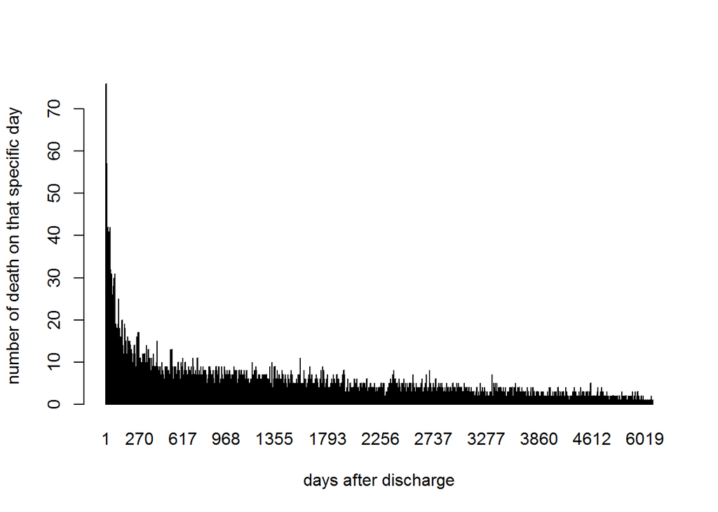

### CCS code 1

#### CCS code 1 that is significantly associated with die30

We find that CCS code 1 is significantly associated with die30 The CCS code1 descriptions that have significant association are as follows

```
##                                                       names1     P_value
## 1                                 ccs1_Biliary tract disease 0.007032301
## 2 ccs1_Other nutritional; endocrine; and metabolic disorders 0.029816690
## 3                   ccs1_Pancreatic disorders (not diabetes) 0.018741722
## 4                                ccs1_Secondary malignancies 0.025720911
```

#### CCS code 1 that is significantly associated with die1800

We find that CCS code 1 is significantly associated with die1800 The CCS code1 descriptions that have significant association are as follows

```
##                                                                        names2
## 1                                                  ccs1_Biliary tract disease
## 2                              ccs1_Congestive heart failure; nonhypertensive
## 3                       ccs1_Coronary atherosclerosis and other heart disease
## 4                                  ccs1_Intestinal obstruction without hernia
## 5                                                 ccs1_Nonspecific chest pain
## 6                                                         ccs1_Osteoarthritis
## 7                                                        ccs1_Other aftercare
## 8                                    ccs1_Pancreatic disorders (not diabetes)
## 9                                      ccs1_Prolapse of female genital organs
## 10 ccs1_Rehabilitation care; fitting of prostheses; and adjustment of devices
## 11                                                ccs1_Secondary malignancies
##         P_value
## 1  1.037160e-08
## 2  2.116884e-06
## 3  1.234356e-02
## 4  1.159785e-02
## 5  2.444400e-02
## 6  1.711116e-04
## 7  1.041535e-02
## 8  1.943107e-05
## 9  2.067756e-02
## 10 2.212265e-02
## 11 5.060120e-22
```

### CCS code 2

#### CCS code 2 that is significantly associated with die30

We find that CCS code 2 is significantly associated with die30 The CCS code2 descriptions that have significant association are as follows

```
##                                                            names1      P_value
## 1 ccs2_Hypertension with complications and secondary hypertension 0.0351849126
## 2                                   ccs2_Nutritional deficiencies 0.0001661674
## 3                                     ccs2_Secondary malignancies 0.0010898445
```

#### CCS code 2 that is significantly associated with die1800

We find that CCS code 2 is significantly associated with die1800 The CCS code2 descriptions that have significant association are as follows

```
##                                                                                                       names2
## 1                                                                   ccs2_Acute and unspecified renal failure
## 2                                                                          ccs2_Acute posthemorrhagic anemia
## 3                                                                                                ccs2_Asthma
## 4                                                                             ccs2_Benign neoplasm of uterus
## 5                                                                                 ccs2_Biliary tract disease
## 6                                                                                  ccs2_Cardiac dysrhythmias
## 7                                              ccs2_Chronic obstructive pulmonary disease and bronchiectasis
## 8                                                                                 ccs2_Chronic ulcer of skin
## 9                                                                 ccs2_Coagulation and hemorrhagic disorders
## 10                                                 ccs2_Complications of surgical procedures or medical care
## 11                                                            ccs2_Congestive heart failure; nonhypertensive
## 12                                                     ccs2_Coronary atherosclerosis and other heart disease
## 13                                                                          ccs2_Deficiency and other anemia
## 14                                                                 ccs2_Diabetes mellitus with complications
```

[output cut: 77 more lines]

### CCS code 3

#### CCS code 3 that is significantly associated with die30

We find that CCS code 3 is significantly associated with die30 The CCS code3 descriptions that have significant association are as follows

```
##                                                     names1     P_value
## 1                 ccs3_Acute and unspecified renal failure 0.002350780
## 2                               ccs3_Chronic ulcer of skin 0.029750532
## 3               ccs3_Coagulation and hemorrhagic disorders 0.032344260
## 4                            ccs3_Nutritional deficiencies 0.020673844
## 5                    ccs3_Other gastrointestinal disorders 0.007578809
## 6                                ccs3_Other liver diseases 0.032103345
## 7          ccs3_Pleurisy; pneumothorax; pulmonary collapse 0.005358708
## 8  ccs3_Respiratory failure; insufficiency; arrest (adult) 0.015590451
## 9                              ccs3_Secondary malignancies 0.002902010
## 10                                          ccs3_Undefined 0.034930974
```

#### CCS code 3 that is significantly associated with die1800

We find that CCS code 3 is significantly associated with die1800 The CCS code3 descriptions that have significant association are as follows

```
##                                                                                                       names2
## 1                                                                          ccs3_Acute posthemorrhagic anemia
## 2                                                                                                ccs3_Asthma
## 3                                                                 ccs3_Bacterial infection; unspecified site
## 4                                                                                      ccs3_Cancer of breast
## 5                                                                                  ccs3_Cardiac dysrhythmias
## 6                                              ccs3_Chronic obstructive pulmonary disease and bronchiectasis
## 7                                                  ccs3_Complications of surgical procedures or medical care
## 8                                                      ccs3_Coronary atherosclerosis and other heart disease
## 9                                                                           ccs3_Deficiency and other anemia
## 10                                                               ccs3_Diabetes mellitus without complication
## 11                                                                        ccs3_Disorders of lipid metabolism
## 12                                                                                 ccs3_Esophageal disorders
## 13                                                                               ccs3_Essential hypertension
## 14                                                                      ccs3_Fluid and electrolyte disorders
```

[output cut: 59 more lines]

### CCS code 4

#### CCS code 4 that is significantly associated with die30

We find that CCS code 4 is significantly associated with die30 The CCS code4 descriptions that have significant association are as follows

```
##                                                   names1      P_value
## 1               ccs4_Acute and unspecified renal failure 0.0308402438
## 2                              ccs4_Conduction disorders 0.0459226927
## 3  ccs4_Coronary atherosclerosis and other heart disease 0.0226127697
## 4            ccs4_Diabetes mellitus without complication 0.0175385141
## 5                     ccs4_Disorders of lipid metabolism 0.0035886258
## 6                              ccs4_Esophageal disorders 0.0256542379
## 7                            ccs4_Essential hypertension 0.0005367635
## 8                                    ccs4_Osteoarthritis 0.0316035664
## 9                                      ccs4_Osteoporosis 0.0134596195
## 10                  ccs4_Other connective tissue disease 0.0028429636
## 11                           ccs4_Secondary malignancies 0.0297261224
## 12                                ccs4_Thyroid disorders 0.0083869195
```

#### CCS code 4 that is significantly associated with die1800

We find that CCS code 4 is significantly associated with die1800 The CCS code4 descriptions that have significant association are as follows

```
##                                                                   names2
## 1                               ccs4_Acute and unspecified renal failure
## 2                                      ccs4_Acute posthemorrhagic anemia
## 3                                                ccs4_Allergic reactions
## 4                                                 ccs4_Anxiety disorders
## 5                                                            ccs4_Asthma
## 6                             ccs4_Bacterial infection; unspecified site
## 7                                                  ccs4_Cancer of breast
## 8                                              ccs4_Cardiac dysrhythmias
## 9                                            ccs4_Chronic kidney disease
## 10         ccs4_Chronic obstructive pulmonary disease and bronchiectasis
## 11                            ccs4_Coagulation and hemorrhagic disorders
## 12             ccs4_Complications of surgical procedures or medical care
## 13                                             ccs4_Conduction disorders
## 14                        ccs4_Congestive heart failure; nonhypertensive
```

[output cut: 79 more lines]

### season

#### seasons that is significantly associated with die30

The seasons that have significant association are as follows We can find that the season winter is significantly related to the die30, which indicates whether the individual dies in the time window of 30 days after discharge

```
##         names1    P_value
## 1 seasonwinter 0.04721893
```

#### seaasons that is significantly associated with die1800

The seasons that have significant association are as follows We can find that season is not significantly related to the die1800, which indicates whether the individual dies in the time window of 1800 days after discharge

```
## [1] names2  P_value
## <0 rows> (or 0-length row.names)
```

### ZIP code

#### ZIP codes that is significantly associated with die30

The ZIP codes that have significant association are as follows We can find that zip code is significantly related to the die30, which indicates whether the individual dies in the time window of 30 days after discharge

```
##           names1     P_value
## 1  zipcode_90048 0.048536423
## 2  zipcode_91105 0.022100119
## 3  zipcode_91367 0.037728114
## 4  zipcode_92037 0.012019488
## 5  zipcode_92123 0.012081555
## 6  zipcode_92653 0.018628371
## 7  zipcode_94115 0.014193484
## 8  zipcode_94596 0.001057508
## 9  zipcode_94705 0.026920659
## 10 zipcode_95119 0.037935675
```

#### ZIP codes that is significantly associated with die1800

```
##          names2    P_value
## 1 zipcode_90505 0.01375748
## 2 zipcode_91360 0.01262534
## 3 zipcode_92103 0.03231716
## 4 zipcode_92373 0.04868250
## 5 zipcode_92835 0.03079069
## 6 zipcode_93720 0.00101477
```

# Conclusion

It is obvious that the longer the time window is, the more people die. And risk of death just monotonously increases when the time window become longer. Generally, the farther away from the discharge, the less risk of death on that specific day

Then I do the classic logistic regression( no penalty for more predictors) and I find that there are some CCS code 1, CCS code 2, CCS code 3, CCS code 4 and zip code that are significantly associated with die30 and die1800 adjusted for other variables. Season is only significantly associated to die 30, adjusted for other variables